# STAT380_HW9

Jackie Yang

Due: Due on Thursday, April 24, 2025 by 11:59 PM)

## Instructions

In class, we introduced 3 methods for selecting the features to be included in a model (forward, backward, LASSO). The activities that follow are meant to provide further practice with these concepts. NOTE: All required `library` commands **must be** included in the Front Matter section. If you include your `library` commands elsewhere in your code, you will be penalized.

At the conclusion to the activity, you should upload

1. your .html file named LastnameFirstInitial_STAT380_HW9.html
2. your .Rmd file named LastnameFirstInitial_STAT380_HW9.Rmd

## Learning Objectives

This assignment address aspects of the following learning objectives.

1. Students will be able to load datasets from R packages and external sources into the R environment.
2. Given a statistical learning method, students will be able to restructure the data for use in the corresponding R function.
3. Identify the best subset of predictors for a linear regression model using subset selection methods, such as best subsets or stepwise regression, using statistical software.
4. Apply shrinkage/regularization methods for estimating parameters using statistical software, including selecting a value for the tuning parameter using cross validation.
5. Interpret the results of LASSO in the context of feature selection.
6. Compare the ability of competing models to generalize for new data.

## Front Matter - Clean Environment, Load Libraries, User Defined Functions

```r
rm(list = ls())
#Add libraries as needed
library(dplyr)
library(glmnet)
```

## Problem 1. Baseball Data

`MLB.csv` contains information about a sample of Major League Baseball (MLB) players from the 1986 and 1987 seasons. Variables include:

- PlayerName-Player’s name
- AtBat-Number of times at bat in 1986
- Hits-Number of hits in 1986
- HmRun-Number of home runs in 1986
- Runs-Number of runs in 1986
- RBI-Number of runs batted in in 1986
- Walks-Number of walks in 1986
- Years-Number of years in the major leagues
- CAtBat-Number of times at bat during his career
- Chits-Number of hits during his career
- CHmRun-Number of home runs during his career
- CRuns-Number of runs during his career
- CRBI-Number of runs batted in during his career
- CWalks-Number of walks during his career
- League-factor with levels A (for American) and N (for National) indicating player’s league at the end of 1986
- Division-factor with levels E (for East) and W (for West) indicating player’s division at the end of 1986
- PutOuts-Number of put outs in 1986
- Assists-Number of assists in 1986
- Errors-Number of errors in 1986
- Salary-1987 annual salary on opening day in thousands of dollars
- NewLeague-factor with levels A (for American) and N (for National) indicating player’s league at the beginning of 1987

**Our goal is to predict a baseball player’s 1987 salary on the basis of the other variables in the dataset (excluding player name).**

1. Remove the `PlayerName` column and any players with a missing salary. Name the result `MLB2`. NOTE: `MLB2` should have 263 observations and 20 variables.

```r
MLB <- read.csv("C:/ESSENTIALS/School OS/Junior Spring 2025/STAT 380/Datasets/MLB.csv")

MLB2 <- MLB %>%
  filter(!is.na(Salary)) %>%
  select(-PlayerName)

dim(MLB2)
```

```
## [1] 263  20
```

2. In order to use the `glmnet` and/or `cv.glmnet` function for building LASSO regression models, create the input matrix and response variable vector.

```r
Xmat <- model.matrix(Salary ~ ., data = MLB2)[ , -1]
yvec <- MLB2$Salary
```

3. Using a seed of 321, perform an 85/15 training/validation split.

```r
set.seed(321)
trainInd <- sample(1:nrow(MLB2), floor(0.85*nrow(MLB2)))
set.seed(NULL)

XmatTrain <- Xmat[trainInd, ]
XmatValidation <- Xmat[-trainInd, ]
yvecTrain <- yvec[trainInd]
yvecValidation <- yvec[-trainInd]
```

4. Using a seed of 12345 and 10-fold cross validation on the training data, use the `cv.glmnet` function to create the plot of MSE as a function of $log(\lambda)$. NOTE: The seed mentioned in this problem should not be used to repeat the training/validation split. Instead, it is the seed for the `cv.glmnet` function which will do the 10-fold cross validation for you.

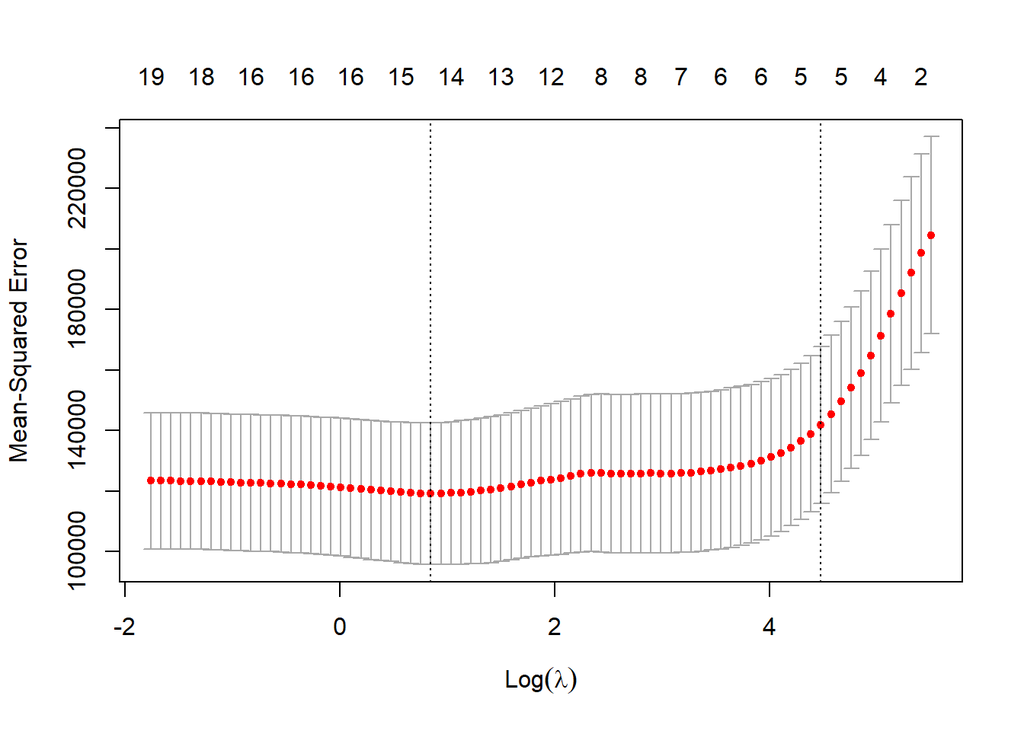

```r
set.seed(12345)
lassoCV <- cv.glmnet(x = XmatTrain,
                     y = yvecTrain,
                     family = "gaussian",
                     alpha = 1,
                     lambda = NULL,
                     standardize = TRUE,
                     nfolds = 10)
set.seed(NULL)

plot(lassoCV)
```

5. What is the optimal $\lambda$ for LASSO regression based on using the minimum value of MSE rule? Which variables are included using this value of $\lambda$?

```r
lassoCV$lambda.min
```

```
## [1] 2.333354
```

```r
coefLamMin <- predict(lassoCV, s = lassoCV$lambda.min, type = "coefficients")

tempdf <-
  data.frame(Variable = row.names(coefLamMin),
             lamMin = as.numeric(coefLamMin))

tempdf
```

```
##       Variable       lamMin
## 1  (Intercept)  163.2781754
## 2        AtBat   -2.3660670
## 3         Hits    7.5513065
## 4        HmRun    1.1695117
## 5         Runs    0.4902876
## 6          RBI    0.0000000
## 7        Walks    5.3416643
## 8        Years  -14.0617073
## 9       CAtBat    0.0000000
## 10       CHits    0.0000000
## 11      CHmRun    0.0000000
## 12       CRuns    0.7275583
## 13        CRBI    0.4558730
## 14      CWalks   -0.5089820
## 15     LeagueN   70.3973102
## 16   DivisionW -106.8440967
## 17     PutOuts    0.3033394
## 18     Assists    0.3027899
## 19      Errors   -3.0147250
## 20  NewLeagueN    0.0000000
```

6. What is the optimal $\lambda$ for LASSO regression based on using the 1-standard error (1SE) rule? Which variables are included using this value of $\lambda$?

```r
lassoCV$lambda.1se
```

```
## [1] 87.84927
```

```r
coefLam1se <- predict(lassoCV, s = lassoCV$lambda.1se, type = "coefficients")

tempdf <-
  data.frame(Variable = row.names(coefLam1se),
             lam1se = as.numeric(coefLam1se))

tempdf
```

```
##       Variable       lam1se
## 1  (Intercept) 188.76059943
## 2        AtBat   0.00000000
## 3         Hits   1.14710006
## 4        HmRun   0.00000000
## 5         Runs   0.00000000
## 6          RBI   0.00000000
## 7        Walks   1.49868914
## 8        Years   0.00000000
## 9       CAtBat   0.00000000
## 10       CHits   0.00000000
## 11      CHmRun   0.00000000
## 12       CRuns   0.22796338
## 13        CRBI   0.19373316
## 14      CWalks   0.00000000
## 15     LeagueN   0.00000000
## 16   DivisionW   0.00000000
## 17     PutOuts   0.07866994
## 18     Assists   0.00000000
## 19      Errors   0.00000000
## 20  NewLeagueN   0.00000000
```

7. Using the value of $\lambda$ associated with the minimum MSE, compute **and interpret** the RMSE on validation data.

```r
lassoYhat <- predict(lassoCV,
                     s = lassoCV$lambda.min,
                     newx = XmatValidation)
lassoMSE <- mean((yvecValidation - lassoYhat)^2)
lassoRMSE <- sqrt(lassoMSE)
lassoRMSE
```

```
## [1] 310.1718
```

Using the value of $\lambda$ associated with the minimum MSE, we get an RMSE of 310.1718, which means that our model’s salary predictions are off by, on average, $310,172 from the actual 1987 salaries.

8. If you were to perform backward elimination for selecting the “best” subset of predictors for predicting salary, which variables would remain in the model?

```r
full_model <- lm(Salary ~ ., data = MLB2)

backward_model <- step(full_model, direction = "backward")
```

```
## Start:  AIC=3046.02
## Salary ~ AtBat + Hits + HmRun + Runs + RBI + Walks + Years +
##     CAtBat + CHits + CHmRun + CRuns + CRBI + CWalks + League +
##     Division + PutOuts + Assists + Errors + NewLeague
##
##             Df Sum of Sq      RSS    AIC
## - CHmRun     1      1138 24201837 3044.0
## - CHits      1      3930 24204629 3044.1
## - Years      1      7869 24208569 3044.1
## - NewLeague  1      9784 24210484 3044.1
## - RBI        1     16076 24216776 3044.2
## - HmRun      1     48572 24249272 3044.6
## - Errors     1     58324 24259023 3044.7
## - League     1     62121 24262821 3044.7
## - Runs       1     63291 24263990 3044.7
## - CRBI       1    135439 24336138 3045.5
## - CAtBat     1    159864 24360564 3045.8
## <none>                   24200700 3046.0
## - Assists    1    280263 24480963 3047.1
## - CRuns      1    374007 24574707 3048.1
## - CWalks     1    609408 24810108 3050.6
## - Division   1    834491 25035190 3052.9
## - AtBat      1    971288 25171987 3054.4
## - Hits       1    991242 25191941 3054.6
## - Walks      1   1156606 25357305 3056.3
## - PutOuts    1   1319628 25520328 3058.0
##
## Step:  AIC=3044.03
## Salary ~ AtBat + Hits + HmRun + Runs + RBI + Walks + Years +
##     CAtBat + CHits + CRuns + CRBI + CWalks + League + Division +
##     PutOuts + Assists + Errors + NewLeague
##
##             Df Sum of Sq      RSS    AIC
## - Years      1      7609 24209447 3042.1
## - NewLeague  1     10268 24212106 3042.2
## - CHits      1     14003 24215840 3042.2
## - RBI        1     14955 24216793 3042.2
## - HmRun      1     52777 24254614 3042.6
## - Errors     1     59530 24261367 3042.7
## - League     1     63407 24265244 3042.7
```

[output cut: 164 more lines]

```
## Salary ~ AtBat + Hits + Walks + CAtBat + CRuns + CRBI + CWalks +
##     Division + PutOuts + Assists
##
##            Df Sum of Sq      RSS    AIC
## <none>                  24500402 3031.3
## - Assists   1    313650 24814051 3032.6
## - CAtBat    1    534156 25034558 3034.9
## - Division  1    798473 25298875 3037.7
## - CWalks    1    965875 25466276 3039.4
## - CRuns     1   1265082 25765484 3042.5
## - Walks     1   1290168 25790569 3042.8
## - CRBI      1   1326770 25827172 3043.1
## - PutOuts   1   1551523 26051925 3045.4
## - AtBat     1   1589780 26090181 3045.8
## - Hits      1   1716068 26216469 3047.1
```

Using backward elimination to select the “best” subset of predictors for predicting salary, the variables that would remain in the model include `Assists`, `CAtBat`, `Division`, `CWalks`, `CRuns`, `Walks`, `CRBI`, `PutOuts`, `AtBat`, and `Hits`.

1. Based on the RMSE for the validation data, which model (the model selected by LASSO regression with $\lambda$ based on the minimum MSE OR the model selected by backward elimination) produced a better RMSE on the validation data? Justify your answer. (Your answer should include the value of the RMSE for both models.)

```r
lassoYhat <- predict(lassoCV,
                     s = lassoCV$lambda.min,
                     newx = XmatValidation)
lassoMinMSE <- mean((yvecValidation - lassoYhat)^2)
lassoMinRMSE <- sqrt(lassoMSE)


MLB2_train <- MLB2[trainInd, ]
MLB2_validation <- MLB2[-trainInd, ]

backwardYhat <- predict(backward_model, newdata = MLB2_validation)

backwardMSE <- mean((MLB2_validation$Salary - backwardYhat)^2)
backwardRMSE <- sqrt(backwardMSE)

cat("Minimum MSE Lambda RMSE: ", lassoMinRMSE, "\n")
```

```
## Minimum MSE Lambda RMSE:  310.1718
```

```r
cat("Backward Selection RMSE: ", backwardRMSE)
```

```
## Backward Selection RMSE:  271.4275
```

The model selected by LASSO regression with $\lambda$ based on the minimum MSE has an RMSE of 310.1718 and the model selected by backward elimination has an RMSE of 271.4275. As the model selected by backward elimination has a smaller RMSE, it performed better on the validation data.